# Introduction

Here is a simple approach to prediction of annual water usage where I practiced time-series forecasting.

**Box-Jenkins Method is used for data analysis using non-seasonal ARIMA (non-stationary) model.**

The dataset provides the annual water usage in Baltimore from 1885 to 1963, or 79 years of data.

The values are in the units of liters per capita per day, and there are 79 observations.

The dataset is credited to Hipel and McLeod, 1994.

The RMSE performance measure and walk-forward validation are used for model evaluation.

Literature:

[Time Series Analysis and Forecasting by Example](https://books.google.si/books/about/Time_Series_Analysis_and_Forecasting_by.html?id=Bqm5kJC8hgMC&printsec=frontcover&source=kp_read_button&redir_esc=y#v=onepage&q&f=false)

[How to Remove Trends and Seasonality with a Difference Transform in Python](https://machinelearningmastery.com/remove-trends-seasonality-difference-transform-python/)

[Autocorrelation in Time Series Data](https://www.influxdata.com/blog/autocorrelation-in-time-series-data/)

## Import libraries

```python
from matplotlib import pyplot
import matplotlib.cm as cm
%matplotlib inline

import numpy as np

from pandas import read_csv, concat, Grouper, DataFrame, datetime, Series
from pandas.plotting import lag_plot, autocorrelation_plot

import warnings
from statsmodels.tsa.arima_model import ARIMA, ARIMAResults
from statsmodels.graphics.tsaplots import plot_acf, plot_pacf
from statsmodels.tsa.stattools import adfuller

from sklearn.metrics import mean_squared_error
```

# Data preparation

### Import data and split to train/test and validation set

```python
series = read_csv('water.csv', header=0, index_col=0, parse_dates=True, squeeze=True)

split_point = len(series) - 10 # how may points for validation

dataset, validation = series[0:split_point], series[split_point:]
print('Dataset: %d time points \nValidation: %d time points' % (len(dataset), len(validation)))

dataset.to_csv('dataset.csv', header=False)
validation.to_csv('validation.csv', header=False)
```

```
Dataset: 69 time points
Validation: 10 time points
```

### Summary statistics

```
count     69.000000
mean     500.478261
std       73.901685
min      344.000000
25%      458.000000
50%      492.000000
75%      538.000000
max      662.000000
Name: 1, dtype: float64
```

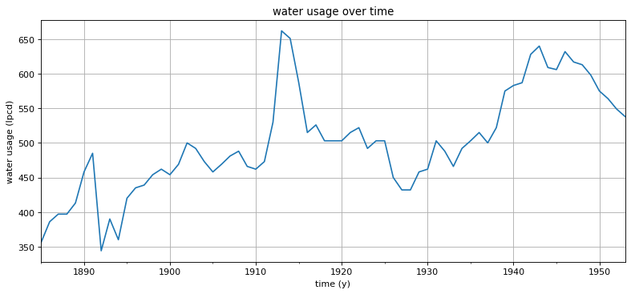

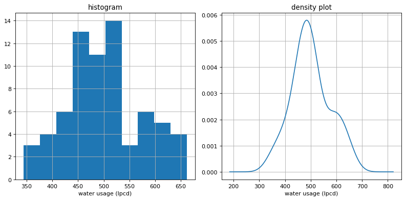

```python
# summary statistics of time series
series = read_csv('dataset.csv', header=None, index_col=0, parse_dates=True, squeeze=True)
print(series.describe())

# line plot
pyplot.figure(num=0, figsize=(5*2.35,5), dpi=80, facecolor='w', edgecolor='k')
series.plot()
pyplot.xlabel('time (y)')
pyplot.ylabel('water usage (lpcd)')
pyplot.title('water usage over time')
pyplot.grid(True)
pyplot.show()

# histogram plot
pyplot.figure(num=1, figsize=(5*2,5), dpi=80, facecolor='w', edgecolor='k')

#pyplot.figure(1)
pyplot.subplot(121)
series.hist()
pyplot.xlabel('water usage (lpcd)')
pyplot.ylabel('')
pyplot.title('histogram')
pyplot.grid(True)


# density plot
pyplot.subplot(122)
series.plot(kind='kde')
pyplot.xlabel('water usage (lpcd)')
pyplot.ylabel('')
pyplot.title('density plot')
pyplot.grid(True)

pyplot.tight_layout()
pyplot.show()
```

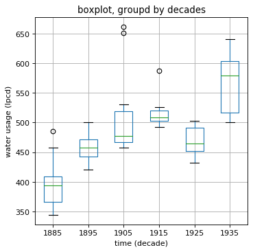

```python
# boxplots of time series, the last decade is omitted

pyplot.figure(num=2, figsize=(5,5), dpi=80, facecolor='w', edgecolor='k')

series = read_csv('dataset.csv', header=None, index_col=0, parse_dates=True, squeeze=True)
groups = series.groupby(Grouper(freq='10YS'))
decades = DataFrame()

for name, group in groups:
    if len(group.values) is 10:
        decades[name.year] = group.values

decades.boxplot()

pyplot.xlabel('time (decade)')
pyplot.ylabel('water usage (lpcd)')
pyplot.title('boxplot, groupd by decades')
pyplot.show()
```

## Persistence model - baseline RMSE

```
Peristence RMSE: 21.975
```

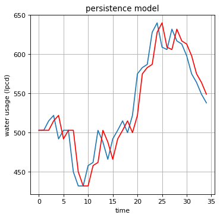

```python
# evaluate a persistence model

# load data
series = read_csv('dataset.csv', header=None, index_col=0, parse_dates=True, squeeze=True)

# prepare data
X = series.values
X = X.astype('float32')
train_size = int(len(X) * 0.50)
train, test_baseline = X[0:train_size], X[train_size:]

# walk-forward / Rolling Window / Rolling Forecast validation
history = [x for x in train]
predictions = list()

for i in range(len(test_baseline)):
    # predict
    yhat = history[-1]
    predictions.append(yhat)
    # observation
    obs = test_baseline[i]
    history.append(obs)
    #print('Predicted=%.3f, Expected=%3.f' % (yhat, obs))

# report performance
rmse = np.sqrt(mean_squared_error(test_baseline, predictions))
print('Peristence RMSE: %.3f' % rmse)

# plot
pyplot.figure(num=2, figsize=(5,5), dpi=80, facecolor='w', edgecolor='k')

pyplot.plot(test_baseline)
pyplot.plot(predictions, color='red')

pyplot.xlabel('time')
pyplot.ylabel('water usage (lpcd)')
pyplot.title('persistence model')
pyplot.grid(True)

pyplot.show()
```

# Manually configure ARIMA

## Detrend data by differencing

```
ADF Statistic: -6.126719
p-value: 0.000000
Critical Values:
	1%: -3.534
	5%: -2.906
	10%: -2.591
```

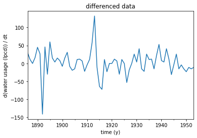

```python
# create and summarize a stationary version of the time series

# create a differenced series
def difference(dataset):
    diff = list()
    for i in range(1, len(dataset)):
        value = dataset[i] - dataset[i - 1]
        diff.append(value)
    return Series(diff)

series = read_csv('dataset.csv', header=None, index_col=0, parse_dates=True, squeeze=True)
X = series.values
X = X.astype('float32')

# difference data for detrending
stationary = difference(X)
stationary.index = series.index[1:]

# check if stationary
result = adfuller(stationary)
print('ADF Statistic: %f' % result[0])
print('p-value: %f' % result[1])
print('Critical Values:')
for key, value in result[4].items():
    print('\t%s: %.3f' % (key, value))

# plot differenced data
stationary.plot()
pyplot.title('differenced data')
pyplot.xlabel('time (y)')
pyplot.ylabel('d(water usage (lpcd)) / dt')
pyplot.show()

# save
stationary.to_csv('stationary.csv', header=False)
```

One step differencing (d=1) appears to be enough.

## Autocorrelation and partial autoorrelation

#### estimates for lag *p* and order of MA model *q*

p is the order (number of time lags) of the autoregressive model

d is the degree of differencing (the number of times the data have had past values subtracted)

q is the order of the moving-average model

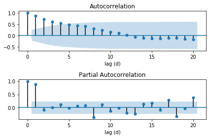

```python
# ACF and PACF plots of the time series

series = read_csv('dataset.csv', header=None, index_col=0, parse_dates=True, squeeze=True)

pyplot.figure()
pyplot.subplot(211)
plot_acf(series, lags=20, ax=pyplot.gca())
pyplot.xlabel('lag (d)')



pyplot.subplot(212)
plot_pacf(series, lags=20, ax=pyplot.gca())
pyplot.xlabel('lag (d)')

pyplot.tight_layout()
pyplot.show()
```

A good starting point for the p is 4 and q as 1.

### Evaluate a manually configured ARIMA model

```python
# load data
series = read_csv('dataset.csv', header=None, index_col=0, parse_dates=True, squeeze=True)

# prepare dataa
X = series.values
X = X.astype('float32')
train_size = int(len(X) * 0.50)
train, test = X[0:train_size], X[train_size:]

# walk-forward validation
history = [x for x in train]
predictions = list()

for i in range(len(test)):
    # predict
    model = ARIMA(history, order=(4,1,1))
    model_fit = model.fit(disp=0)
    yhat = model_fit.forecast()[0]
    predictions.append(yhat)
    # observation
    obs = test[i]
    history.append(obs)
    #print('>Predicted=%.3f, Expected=%3.f' % (yhat, obs))

# report performance
rmse = np.sqrt(mean_squared_error(test, predictions))
print('RMSE: %.3f' % rmse)
```

```
RMSE: 31.097
```

Worse performance than baseline (persistence) model!

# Grid search ARIMA parameters

### Define functions

```python
# evaluate an ARIMA model for a given order (p,d,q) and return RMSE
def evaluate_arima_model(X, arima_order):

    # prepare training dataset
    X = X.astype('float32')
    train_size = int(len(X) * 0.50)
    train, test = X[0:train_size], X[train_size:]
    history = [x for x in train]

    # make predictions
    predictions = list()
    for t in range(len(test)):
        model = ARIMA(history, order=arima_order)

        # model_fit = model.fit(disp=0)
        model_fit = model.fit(trend='nc', disp=0) # disable the automatic addition of a trend constant
        yhat = model_fit.forecast()[0]
        predictions.append(yhat)
        history.append(test[t])

    # calculate out of sample error
    rmse = np.sqrt(mean_squared_error(test, predictions))
    return rmse

# evaluate combinations of p, d and q values for an ARIMA model
def evaluate_models(dataset, p_values, d_values, q_values):

    dataset = dataset.astype('float32')
    best_score, best_order = float("inf"), None

    for p in p_values:
        for d in d_values:
            for q in q_values:

                order = (p,d,q)

                try:
                    rmse = evaluate_arima_model(dataset, order)

                    if rmse < best_score:
                        best_score, best_order = rmse, order

                    print('ARIMA%s - RMSE = %.3f' % (order, rmse))

                except:
                    continue

    print('\nBest: ARIMA%s - RMSE = %.3f' % (best_order, best_score))

    return best_order
```

### Run on dataset

```python
def grid_search(series):

    # evaluate parameters
    p_values = range(0, 3)
    d_values = range(0, 2)
    q_values = range(0, 3)

    warnings.filterwarnings("ignore")

    best_order = evaluate_models(series.values, p_values, d_values, q_values)

    return best_order
```

```python
# load dataset
series = read_csv('dataset.csv', header=None, index_col=0, parse_dates=True, squeeze=True)

# search
best_order = grid_search(series)
```

```
ARIMA(0, 0, 1) - RMSE = 282.657
ARIMA(0, 1, 1) - RMSE = 21.907
ARIMA(0, 1, 2) - RMSE = 22.182
ARIMA(1, 0, 0) - RMSE = 22.203
ARIMA(1, 1, 0) - RMSE = 21.922
ARIMA(2, 0, 0) - RMSE = 22.048
ARIMA(2, 1, 0) - RMSE = 21.733

Best: ARIMA(2, 1, 0) - RMSE = 21.733
```

### Summarize residual errors - *walk-forward validation*

```python
def residual_stats(series, best_order, bias=0):

    print('-----------------------------')

    # prepare data
    X = series.values
    X = X.astype('float32')
    train_size = int(len(X) * 0.50)
    train, test = X[0:train_size], X[train_size:]

    # walk-forward validation
    history = [x for x in train]
    predictions = list()

    for i in range(len(test)):

        # predict
        model = ARIMA(history, order=best_order)
        model_fit = model.fit(trend='nc', disp=0)
        yhat = bias + float(model_fit.forecast()[0])
        predictions.append(yhat)

        # observation
        obs = test[i]
        history.append(obs)

    #report performance
    rmse = np.sqrt(mean_squared_error(test, predictions))
    print('RMSE: %.3f\n' % rmse)

    # errors
    residuals = [test[i]-predictions[i] for i in range(len(test))]
    residuals = DataFrame(residuals)
    residuals_mean = residuals.mean()

    print('RESIDUAL STATISTICS \n')
    print(residuals.describe())

    # plot
    pyplot.figure(num=None, figsize=(5,5), dpi=80, facecolor='w', edgecolor='k')

    pyplot.subplot(211)
    residuals.hist(ax=pyplot.gca())
    pyplot.xlabel('residual')
    pyplot.ylabel('')
    pyplot.title('histogram')
    pyplot.grid(True)

    pyplot.subplot(212)
    residuals.plot(kind='kde', ax=pyplot.gca())
    pyplot.xlabel('residual')
    pyplot.ylabel('')
    pyplot.title('density plot')
    pyplot.grid(True)

    pyplot.tight_layout()
    pyplot.show()

    return residuals_mean
```

```
-----------------------------
RMSE: 21.733

RESIDUAL STATISTICS

               0
count  35.000000
mean    1.081625
std    22.022566
min   -52.103813
25%   -16.202284
50%    -0.459801
75%    12.085093
max    51.284333
```

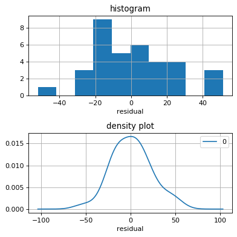

```python
series = read_csv('dataset.csv', header=None, index_col=0, parse_dates=True, squeeze=True)

residuals_mean = residual_stats(series, best_order)
```

We can see that the distribution has a right shift and that the mean is non-zero at around 1.0. This is perhaps a sign that the predictions are biased.

The distribution of residual errors is also plotted. The graphs suggest a Gaussian-like distribution with a longer right tail, providing further evidence that perhaps a power transform might be worth exploring.

We could use this information to bias-correct predictions by adding the mean residual error of 1.081624 to each forecast made.

### Make bias corrected forecasts

```
-----------------------------
RMSE: 21.706

RESIDUAL STATISTICS

                  0
count  3.500000e+01
mean  -2.598556e-14
std    2.202257e+01
min   -5.318544e+01
25%   -1.728391e+01
50%   -1.541426e+00
75%    1.100347e+01
max    5.020271e+01
```

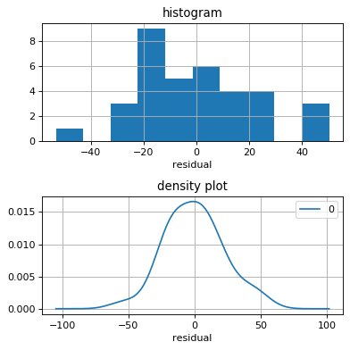

```python
_ = residual_stats(series, best_order, bias = residuals_mean)
```

Not much of an improvement after bias correction.

# Save finalized model to file

```python
# monkey patch around bug in ARIMA class
def __getnewargs__(self):
    return ((self.endog),(self.k_lags, self.k_diff, self.k_ma))

ARIMA.__getnewargs__ = __getnewargs__

def save_model(best_order, model_name):

    # load data
    series = read_csv('dataset.csv', header=None, index_col=0, parse_dates=True, squeeze=True)

    # prepare data
    X = series.values
    X = X.astype('float32')

    # fit model
    model = ARIMA(X, order=best_order)
    model_fit = model.fit(trend='nc', disp=0)

    # bias constant
    bias = residuals_mean

    # save model
    model_fit.save(f'model_{model_name}.pkl')
    np.save(f'model_bias_{model_name}.npy', [bias])
```

```python
save_model(best_order_box, model_name='simple')
```

# Load and evaluate the finalized model on the validation dataset

```python
def validate_models(model_names):

    # load train dataset
    dataset = read_csv('dataset.csv', header=None, index_col=0, parse_dates=True, squeeze=True)
    X = dataset.values.astype('float32')
    history = [x for x in X]

    # load validation dataset
    validation = read_csv('validation.csv', header=None, index_col=0, parse_dates=True, squeeze=True)
    y = validation.values.astype('float32')

    # plot
    pyplot.figure(num=None, figsize=(5,5), dpi=80, facecolor='w', edgecolor='k')
    pyplot.plot(y, color=cm.Set1(0), label='actual')


    for ind, model_name in enumerate(model_names):

        # load model
        model_fit = ARIMAResults.load(f'model_{model_name}.pkl')
        bias = np.load(f'model_bias_{model_name}.npy')

        # make first prediction
        predictions = np.ones(len(y))
        yhat = bias + float(model_fit.forecast()[0])
        predictions[0] = yhat
        history.append(y[0])
        #print('>Predicted=%.3f, Expected=%3.f' % (yhat, y[0]))

        # rolling forecasts
        for i in range(1, len(y)):

            # predict
            model = ARIMA(history, order=(2,1,0))
            model_fit = model.fit(trend='nc', disp=0)
            yhat = bias + float(model_fit.forecast()[0])
            predictions[i] = yhat

            # observation
            obs = y[i]
            history.append(obs)
        #    print('>Predicted=%.3f, Expected=%3.f' % (yhat, obs))

        rmse = np.sqrt(mean_squared_error(y, predictions))
        print(f'RMSE {model_name}: %.3f' % rmse)

        pyplot.plot(predictions, color=cm.Set1(ind+1), label=f'{model_name} predict')

    pyplot.xlabel('time (d)')
    pyplot.ylabel('water usage (lpcd)')
    pyplot.title('Validation')

    pyplot.legend()
    pyplot.grid(True)

    pyplot.show()
```

```
RMSE simple: 16.955
```

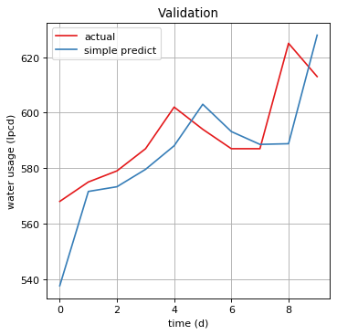

```python
validate_models(model_names=['simple'])
```

# Comparison of detrend approaches

### Linear detrend & Box-Cox transform

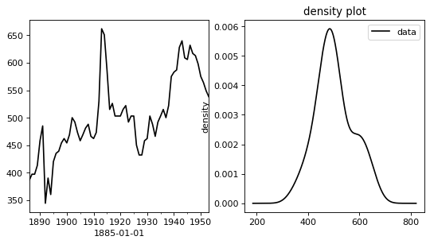

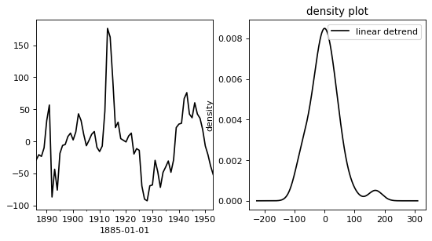

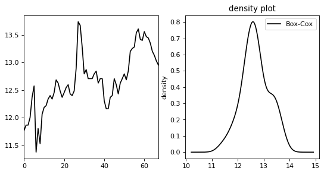

```python
from statsmodels.tsa.tsatools import detrend
from scipy.stats import boxcox

figsize = (8,4)

series = read_csv('dataset.csv', header=0, index_col=0, parse_dates=True, squeeze=True)
#print(series.describe())
pyplot.figure(num=None, figsize=figsize, dpi=80, facecolor='w', edgecolor='k')

pyplot.subplot(121)
series.plot(color='k', label='data')
pyplot.subplot(122)
series.plot(kind='kde', color='k', label='data')

pyplot.xlabel('')
pyplot.ylabel('density')
pyplot.title('density plot')

pyplot.legend()
pyplot.show()


# --- linear detrend ---
series_linear = detrend(series)
#print(result.describe())
pyplot.figure(num=None, figsize=figsize, dpi=80, facecolor='w', edgecolor='k')

pyplot.subplot(121)
series_linear.plot(color='k', label='linear detrend')
pyplot.subplot(122)
series_linear.plot(kind='kde', color='k', label='linear detrend')

pyplot.xlabel('')
pyplot.ylabel('density')
pyplot.title('density plot')

pyplot.legend()
pyplot.show()

# --- Box-Cox transform ---
series_boxcox, lam = boxcox(series)
series_boxcox = Series(series_new)

# plot
pyplot.figure(num=None, figsize=figsize, dpi=80, facecolor='w', edgecolor='k')

pyplot.subplot(121)
series_boxcox.plot(color='k', label='Box-Cox')
pyplot.subplot(122)
series_boxcox.plot(kind='kde', color='k', label='Box-Cox')

pyplot.xlabel('')
pyplot.ylabel('density')
pyplot.title('density plot')

pyplot.legend()
pyplot.show()
```

```python
best_order_simple = grid_search(series)
best_order_linear = grid_search(series_linear)
best_order_boxcox = grid_search(series_boxcox)
```

[output not shown]

```
-----------------------------
RMSE: 22.062

RESIDUAL STATISTICS

               0
count  34.000000
mean    1.079138
std    22.366475
min   -52.104758
25%   -16.187762
50%    -0.622213
75%    12.013779
max    51.384143
```

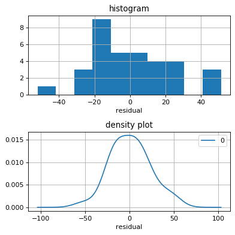

```
-----------------------------
RMSE: 22.103

RESIDUAL STATISTICS

               0
count  34.000000
mean   -1.721260
std    22.366999
min   -54.877247
25%   -18.808632
50%    -3.529888
75%     9.165272
max    48.569455
```

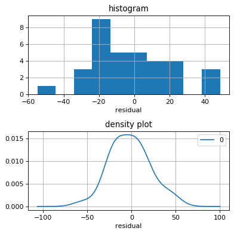

```
-----------------------------
RMSE: 0.158

RESIDUAL STATISTICS

               0
count  34.000000
mean    0.008019
std     0.160375
min    -0.398270
25%    -0.096499
50%    -0.001456
75%     0.087467
max     0.365552
```

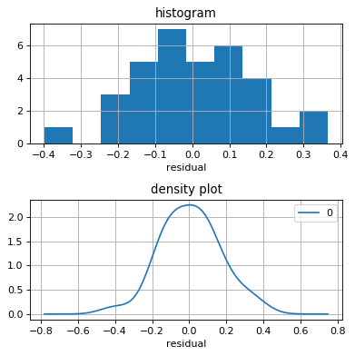

```python
_ = residual_stats(series, best_order)
_ = residual_stats(series_linear, best_order)
_ = residual_stats(series_boxcox, best_order)
```

```
RMSE simple: 16.532
RMSE linear: 16.512
RMSE boxcox: 16.898
```

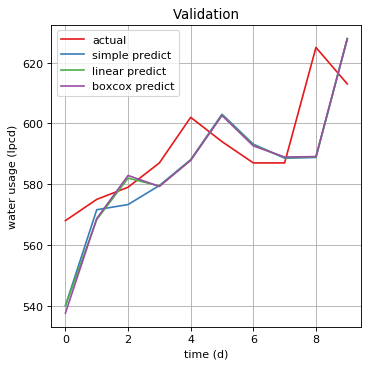

```python
save_model(best_order_simple, model_name='simple')
save_model(best_order_linear, model_name='linear')
save_model(best_order_boxcox, model_name='boxcox')

validate_models(model_names = ['simple', 'linear', 'boxcox'])
```